# Reproducible Research: Peer Assessment 2

# Data Analysis Report of Health and Economic Impact by Severe Weather Events

## Author:Mahantesh Pattanshetti

## Synopsis:

This report attempts to analyze data provided by U.S. National Oceanic and Atmospheric Administration’s (NOAA) to come up with meaningful data points that Government can use to make major policy decisions. The objective of the report is to aid Goverment to with decisions such as - Whether to allocate substantially higher research captial to studying Tornados or Avalanche ? - How can Government increase its proactive role in aftermath of disasters given the expected level of damage ? - How can Government educate US farmers and property owners about myth vs facts and help them better prepare for  
crisis ?

## Data Processing:

The zipped data file (https://d396qusza40orc.cloudfront.net/repdata%2Fdata%2FStormData.csv.bz2) is downloaded,unzipped and loaded into data frame.

```r
library(plyr)
library(dplyr)
```

```r
if(!file.exists("data/repdata_data_StormData.csv"))
  download.file("http://d396qusza40orc.cloudfront.net/repdata%2Fdata%2FStormData.csv.bz2", destfile="repdata_data_StormData.csv")

stormData = read.csv("repdata_data_StormData.csv")
```

Next,filter the data frame to select the rows with the following data set of interest to this study.

- EVTYPE (type of event)
- FATALITIES
- INJURIES
- PROPDMG
- PROPDMGEXP
- CROPDMG
- CROPDMGEXP

```r
## Retain only necessary data and remove the original data
cleanedStortData <- stormData[,c("EVTYPE", "FATALITIES", "INJURIES", "PROPDMG", "PROPDMGEXP", "CROPDMG", "CROPDMGEXP")]
remove(stormData)
```

```r
cleanedStortData$PROPDMGEXP <- as.character(cleanedStortData$PROPDMGEXP)
cleanedStortData$PROPDMGEXP = gsub("\\-|\\+|\\?|h|H|0","0",cleanedStortData$PROPDMGEXP)
cleanedStortData$PROPDMGEXP = gsub("k|K", "1000", cleanedStortData$PROPDMGEXP)
cleanedStortData$PROPDMGEXP = gsub("m|M", "1000000", cleanedStortData$PROPDMGEXP)
cleanedStortData$PROPDMGEXP = gsub("b|B", "1000000000", cleanedStortData$PROPDMGEXP)
cleanedStortData$PROPDMGEXP <- as.numeric(cleanedStortData$PROPDMGEXP)
cleanedStortData$PROPDMGEXP[is.na(cleanedStortData$PROPDMGEXP)] = 0

cleanedStortData$CROPDMGEXP <- as.character(cleanedStortData$CROPDMGEXP)
cleanedStortData$CROPDMGEXP = gsub("\\-|\\+|\\?|h|H|0","0",cleanedStortData$CROPDMGEXP)
cleanedStortData$CROPDMGEXP = gsub("k|K", "1000", cleanedStortData$CROPDMGEXP)
cleanedStortData$CROPDMGEXP = gsub("m|M", "1000000", cleanedStortData$CROPDMGEXP)
cleanedStortData$CROPDMGEXP = gsub("b|B", "1000000000", cleanedStortData$CROPDMGEXP)
cleanedStortData$CROPDMGEXP <- as.numeric(cleanedStortData$CROPDMGEXP)
cleanedStortData$CROPDMGEXP[is.na(cleanedStortData$CROPDMGEXP)] = 0

cleanedStortData <- mutate(cleanedStortData, PROPDMGVAL= PROPDMG * PROPDMGEXP, CROPDMGVAL= CROPDMG * CROPDMGEXP)
```

# Aggregate the data

```r
TotalFatalities <- aggregate(FATALITIES ~ EVTYPE, data = cleanedStortData, FUN = sum)
TotalInjuries <- aggregate(INJURIES ~ EVTYPE, data = cleanedStortData, FUN = sum)
TotalPropertyDamage <- aggregate(PROPDMGVAL ~ EVTYPE, data = cleanedStortData, FUN = sum)
TotalCropDamage <- aggregate(CROPDMGVAL ~ EVTYPE, data = cleanedStortData, FUN = sum)
```

## Results:

Across the United States, Which types of events are nost harmful with respect to population health?

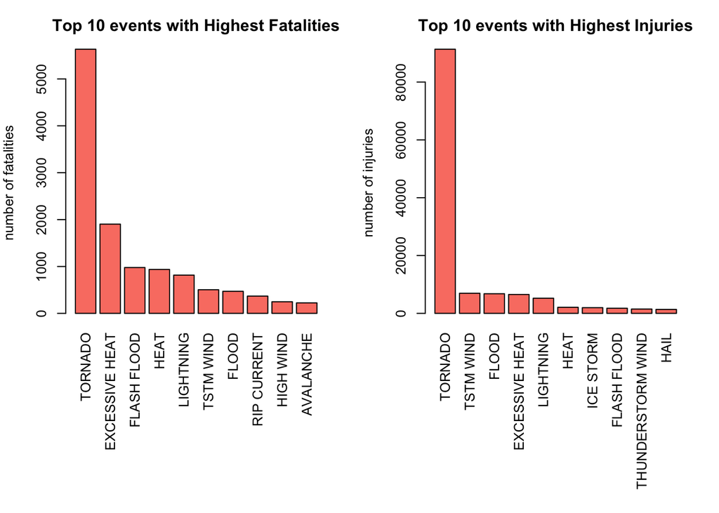

```r
# get top10 event with highest fatalities
TopTen_Fatalities <- TotalFatalities[order(-TotalFatalities$FATALITIES), ][1:10, ]
# get top10 event with highest injuries
TopTen_Injuries <- TotalInjuries[order(-TotalInjuries$INJURIES), ][1:10, ]
par(mfrow = c(1, 2), mar = c(12, 4, 3, 2), mgp = c(3, 1, 0), cex = 0.8)
barplot(TopTen_Fatalities$FATALITIES, las = 3, names.arg = TopTen_Fatalities$EVTYPE, main = "Top 10 events with Highest Fatalities",
    ylab = "number of fatalities", col = "salmon")
barplot(TopTen_Injuries$INJURIES, las = 3, names.arg = TopTen_Injuries$EVTYPE, main = "Top 10 events with Highest Injuries",
    ylab = "number of injuries", col = "salmon")
```

Across the United States, which types of events have the greatest economic consequences?

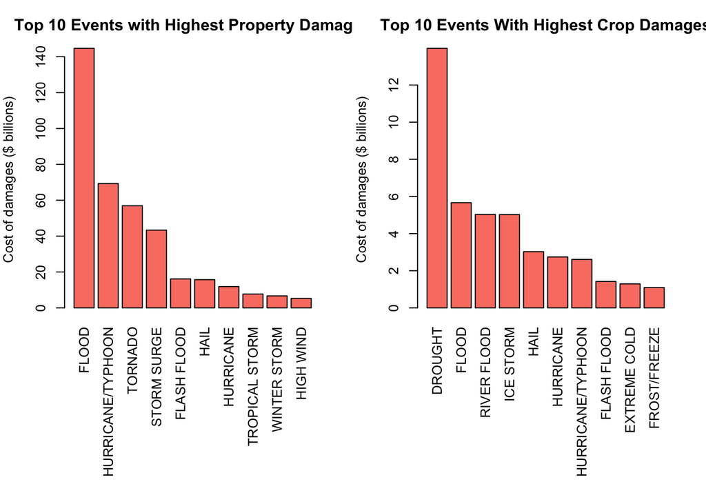

```r
# get top 10 events with highest property damage
TopTen_PropertyDamages <- TotalPropertyDamage[order(-TotalPropertyDamage$PROPDMGVAL), ][1:10, ]
# get top 10 events with highest crop damage
TopTen_CropDamages <- TotalCropDamage[order(-TotalCropDamage$CROPDMGVAL), ][1:10, ]
par(mfrow = c(1, 2), mar = c(12, 4, 3, 2), mgp = c(3, 1, 0), cex = 0.8)
barplot(TopTen_PropertyDamages$PROPDMGVAL/(10^9), las = 3, names.arg = TopTen_PropertyDamages$EVTYPE,
    main = "Top 10 Events with Highest Property Damages", ylab = "Cost of damages ($ billions)",
    col = "salmon")
barplot(TopTen_CropDamages$CROPDMGVAL/(10^9), las = 3, names.arg = TopTen_CropDamages$EVTYPE,
    main = "Top 10 Events With Highest Crop Damages", ylab = "Cost of damages ($ billions)",
    col = "salmon")
```